# Suite SDK Demo - Few-Shot Object Detection from Weakly Labeled Data

In this SDK Demo, we demonstrate how you can efficiently train a model on a new set of object classes, and use it for semi-automatic bounding box labeling.

Specifically, we show how to :

- **prepare a small dataset** of images and image-level classes that a model has never been trained on,
- **train an Object Detection model** on these new classes in a **weakly supervised, few-shot learning** scheme, and
- use the trained model to **automatically annotate these new class of objects using bounding boxes**.

We will walk to through the demo in this order:

1. Create a New Project on the Suite Web UI
2. Set System Requirements
3. Initialize System and SDK
4. Upload Images to the Suite
5. Weakly-Annotate Uploaded Images with Image-Level Classes
6. Few-Shot Training an Object Detector using Weakly-Labeled Data
7. Automatically Label Bounding Boxes in Your Images Using the Few-Shot Object Detector
8. Example Results

## Create a New Project on the Superb AI Suite Web UI

### - Select data type and annotation type

For `Data Type`, select `Image`. For `Annotation Type`, select `Box` and `Image Category`.

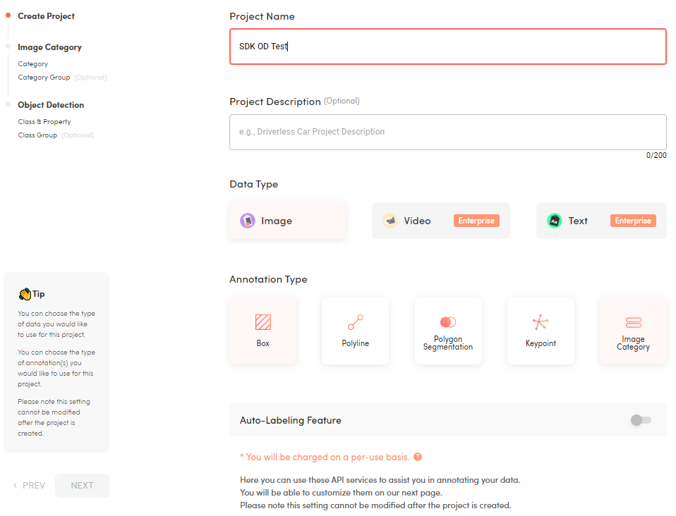

### - Add image category list

Add these image categories on the Suite Web UI:

- Required: `bugatti`, `cleaner`, `gpu`, `sadcat`
- Optional: `butterflyknife`, `fidgetspinner`, `garfield`, `spiderman`, `ted`, `teslaroadster`, `vr`, `yeezy`

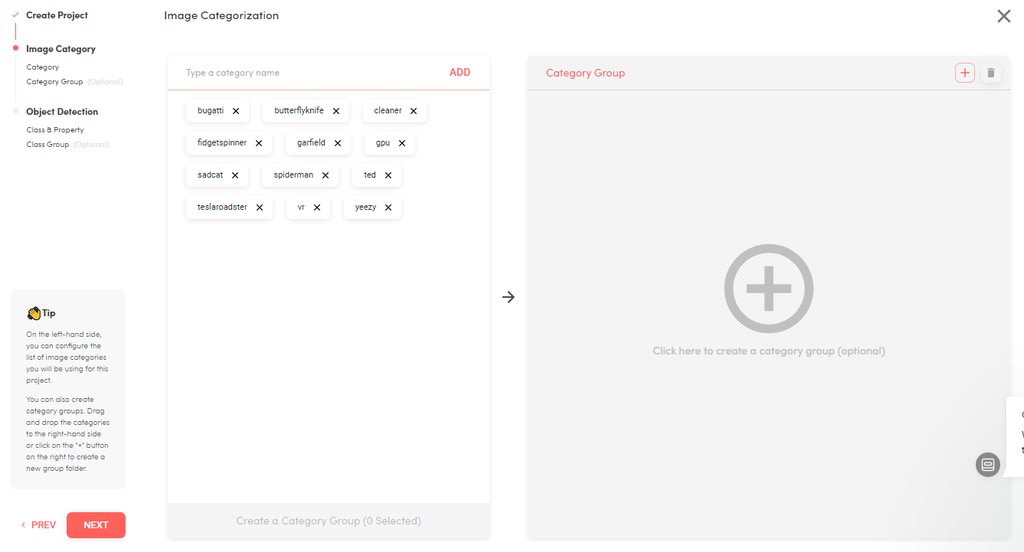

### - Add object class list

Also add the same classes for the `Box` object type. Finish creating the project with this configuration.

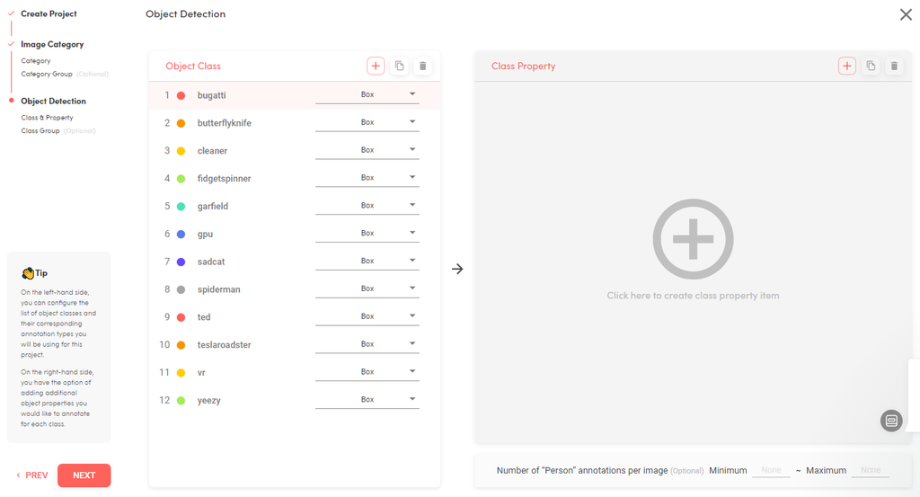

## Initialize System and SDK

### - Set System Requirement

```python
import init
import os, sys, logging
import cv2

sys.path.insert(0, 'lib')
from configs.faster.default_configs import config, update_config
import numpy as np

# get config
os.environ['PYTHONUNBUFFERED'] = '1'
os.environ['MXNET_CUDNN_AUTOTUNE_DEFAULT'] = '0'
os.environ['MXNET_ENABLE_GPU_P2P'] = '0'
update_config('./configs/faster/res101_mx_3k.yml')

# for Superb AI Suite SDK
os.environ['LC_ALL'] = 'C.UTF-8'
os.environ['LANG'] = 'C.UTF-8'

import mxnet as mx

from demo.tictoc import tic, toc
```

### - Initialize Suite SDK

Go to the `My Account > Advanced` menu create an Access API Key. Click on the `Copy` button to copy your access key to clipboard.

Your `Account Name` is the name you used for login Suite. You can find this on the upper-left corner of Suite Web UI.

Once you find your `Account Name` and `Access API Key`, follow the instruction in the comment below.

```python
# modify below line as "<your account name>\n<your Access API Key>\n"
!printf "<account_name>\n<API_key>\n" | spb configure

import spb

print(spb.__version__)
```

```
Suite Account Name: Access Key: Profile default is counfigured with account name 'pingu'.
0.0.34
```

### - Get a Handler for Your Project

Use the function below to get a handler for your project.

You'll use this to upload data to the project, update annotations and download them for model training.

```python
def get_spb_project(project_name):
    command = spb.Command(type='describe_project')

    projects, num_of_projects = spb.run(command=command, option={'name': project_name}, page=1, page_size=1)

    if num_of_projects == 0:
        raise Exception('Project {} not found'.format(project_name))
    assert num_of_projects == 1

    return projects[0]

# get a handler for the project you created through the Suite Web UI
project = get_spb_project('SDK OD Test')

print('Project ID: {}'.format(project.id))
print('Project Name: {}'.format(project.name))
```

```
Project ID: 1ace2624-3395-433b-a67f-7a6a7b5de064
Project Name: SDK OD Test
```

## Upload Images to the Suite

### - Get a list of your images

For this demo, we've prepared in your docker container some images of these 12 classes: `bugatti`, `cleaner`, `gpu`, `sadcat`, `spiderman`, `butterflyknife`, `fidgetspinner`, `garfield`, `ted`, `teslaroadster`, `vr`, `yeezy`.

For each class, there are about 100 images. You can freely choose any subset among those classes.

```python
def get_image_list(image_root, class_names):
    files = []
    for idx, c in enumerate(class_names):
        files_c = [os.path.join(image_root, c, f) for f in os.listdir(os.path.join(image_root, c))
                   if os.path.isfile(os.path.join(image_root, c, f)) and f.split('.')[-1] in ['jpg', 'png']]
        files.append(files_c)
    return files

# change the list to choose any subset of images among these classes: `bugatti`, `cleaner`, `gpu`,
# `sadcat`, `spiderman`, `butterflyknife`, `fidgetspinner`, `garfield`, `ted`, `teslaroadster`, `vr`, `yeezy`
class_names = ['bugatti', 'cleaner', 'gpu', 'sadcat']

image_root = './demo/image'
files = get_image_list(image_root, class_names)

print(', '.join(['{}: {} files'.format(name, len(files_c)) for name, files_c in zip(class_names, files)]))
```

```
bugatti: 115 files, cleaner: 111 files, gpu: 116 files, sadcat: 95 files
```

### - Split Your Images into Train-Set and Val-Set

```python
def random_split_into_train_val(files, num_val_per_class):
    train_files = []
    val_files = []

    for files_c in files:
        assert num_val_per_class < len(files_c)

        indices = list(range(len(files_c)))
        np.random.shuffle(indices)
        indices = indices[:num_val_per_class]
        indices.sort()

        for idx, f in enumerate(files_c):
            if idx in indices:
                val_files.append(f)
            else:
                train_files.append(f)

    return train_files, val_files

# specify the size of validation set for each class
num_val_per_class = 50

train_files, val_files = random_split_into_train_val(files, num_val_per_class)

print('{} train files, {} val files'.format(len(train_files), len(val_files)))
```

```
237 train files, 200 val files
```

### - Upload Images to the Suite

```python
def upload_images_to_spb(project, dataset_name, files):
    command = spb.Command(type='create_data')

    print('Upload images...')
    tic()

    for idx, f in enumerate(files):
        name = f.split('/')[-1]
        key = dataset_name + '_' + name
        option = {'file': f, 'file_name': name, 'dataset': dataset_name, 'data_key': key}

        try:
            spb.run(command=command, optional={'projectId': project.id}, option=option)

            if (idx + 1) % 50 == 0:
                print('Upload {}/{}: {} -> {}, {:.1f} seconds spent.'.format(idx + 1, len(files), f, key, toc()))

        except Exception as e:
            print('[Exception {}] Upload {}/{}: {} -> {}'.format(str(e), idx + 1, len(files), f, key))

    print('Done: {:.1f} seconds spent.'.format(toc()))

spb_train_name = 'train_' + project.name.replace(' ', '_')
spb_val_name = 'val_' + project.name.replace(' ', '_')

# train and validation sets are uploaded to two different datasets, which are equivalent to "folders"
upload_images_to_spb(project, spb_train_name, train_files)
upload_images_to_spb(project, spb_val_name, val_files)
```

```
Upload images...
Upload 50/237: ./demo/image/bugatti/bugatti_76.jpg -> train_SDK_OD_Test_bugatti_76.jpg, 24.0 seconds spent.
Upload 100/237: ./demo/image/cleaner/cleaner_1.jpg -> train_SDK_OD_Test_cleaner_1.jpg, 46.7 seconds spent.
Upload 150/237: ./demo/image/gpu/gpu_52.jpg -> train_SDK_OD_Test_gpu_52.jpg, 69.8 seconds spent.
Upload 200/237: ./demo/image/sadcat/sadcat_46.jpg -> train_SDK_OD_Test_sadcat_46.jpg, 90.7 seconds spent.
Done: 106.0 seconds spent.
Upload images...
Upload 50/200: ./demo/image/bugatti/bugatti_24.jpg -> val_SDK_OD_Test_bugatti_24.jpg, 23.3 seconds spent.
Upload 100/200: ./demo/image/cleaner/cleaner_67.jpg -> val_SDK_OD_Test_cleaner_67.jpg, 45.4 seconds spent.
Upload 150/200: ./demo/image/gpu/gpu_28.jpg -> val_SDK_OD_Test_gpu_28.jpg, 65.9 seconds spent.
Upload 200/200: ./demo/image/sadcat/sadcat_80.jpg -> val_SDK_OD_Test_sadcat_80.jpg, 84.9 seconds spent.
Done: 84.9 seconds spent.
```

## Weakly-Annotate Uploaded Images with Image-Level Classes

Normally, you would need to annotate images with bounding box and object class labels to train an object detection model.

For this example, we demonstrate **training an object detection model only using image-level classes** (without any bounding box annotations).

### - Get a handler of uploaded images

```python
def get_spb_data(project):
    command = spb.Command(type='describe_label')
    option = {'project_id': project.id}
    page_size = 10

    print('Get uploaded data handler...')
    tic()

    try:
        data, num_data = spb.run(command=command, option=option, page=1, page_size=page_size)
        num_pages = int(np.ceil(float(num_data) / page_size))
    except Excetion as e:
        print('[Exception {}] Load page {}'.format(str(e), 1))
        return []

    for idx in range(1, num_pages):
        try:
            data_pg, _ = spb.run(command=command, option=option, page=idx+1, page_size=page_size)
            data = data + data_pg

            if (idx + 1) % 10 == 0:
                print('Load page {}/{}: {:.1f} seconds spent.'.format(idx + 1, num_pages, toc()))

        except Excetion as e:
            print('[Exception {}] Load page {}/{}'.format(str(e), idx + 1, num_pages))

    print('Done: {:.1f} seconds spent.'.format(toc()))
    return data

spb_data = get_spb_data(project)
```

```
Get uploaded data handler...
Load page 10/44: 5.9 seconds spent.
Load page 20/44: 11.8 seconds spent.
Load page 30/44: 17.5 seconds spent.
Load page 40/44: 23.3 seconds spent.
Done: 25.3 seconds spent.
```

### - Label uploaded images with image-level classes

Here, we assume that all image files names start with their image-level classes.

For example, the name of an image file of a `bugatti` class is formatted as "`bugatti_98.jpg`".

```python
def annotate_image_category(project, spb_data):
    command = spb.Command(type='update_label')
    class_name_to_spb_id = {c['name']: c['id']
                            for c in project.label_interface['categorization']['word_map'] if c['id'] != 'root'}

    print('Image-level class labeling...')
    tic()

    for idx, d in enumerate(spb_data):
        class_name = d.data_key.split('_')[-2]
        d.result = {'objects': [], 'categorization': {'value': [class_name_to_spb_id[class_name]]}}

        try:
            d = spb.run(command=command, option=d)

            if (idx + 1) % 50 == 0:
                print('Annotate {}/{}: {} -> {}, {:.1f} seconds spent.'.format(idx + 1, len(spb_data), class_name, d.data_key, toc()))

        except Exception as e:
            print('[Exception {}] Annotate {}/{}: {} -> {}'.format(str(e), idx + 1, len(spb_data), class_name, d.data_key))

    print('Done: {:.1f} seconds spent.'.format(toc()))

annotate_image_category(project, spb_data)
```

```
Image-level class labeling...
Annotate 50/437: bugatti -> train_SDK_OD_Test_bugatti_76.jpg, 14.7 seconds spent.
Annotate 100/437: cleaner -> train_SDK_OD_Test_cleaner_1.jpg, 28.5 seconds spent.
Annotate 150/437: gpu -> train_SDK_OD_Test_gpu_52.jpg, 43.0 seconds spent.
Annotate 200/437: sadcat -> train_SDK_OD_Test_sadcat_46.jpg, 57.4 seconds spent.
Annotate 250/437: bugatti -> val_SDK_OD_Test_bugatti_33.jpg, 72.0 seconds spent.
Annotate 300/437: cleaner -> val_SDK_OD_Test_cleaner_68.jpg, 86.3 seconds spent.
Annotate 350/437: gpu -> val_SDK_OD_Test_gpu_1.jpg, 100.6 seconds spent.
Annotate 400/437: sadcat -> val_SDK_OD_Test_sadcat_88.jpg, 115.1 seconds spent.
Done: 125.7 seconds spent.
```

## Few-Shot Training an Object Detector using Weakly-Labeled Data

Now, we use the weakly-labeled dataset we prepared above to train an object detector model.

In this example, we first use a pre-trained `R-FCN-3000 object detector` [(link to paper)](https://arxiv.org/abs/1712.01802) model as a feature extractor, and then append a simple Linear Classification head that will be few-shot trained with the weakly-labeled dataset.

You may choose to use a different architecture for the feature extractor and the classification head.

### - Load images and weak-labels (image-level classes) from Suite

```python
import skimage.io
from demo.image import resize, transform

def load_and_transform_spb_images(project, spb_data, class_names):
    images = []
    im_infos = []
    mx_data = []
    labels = []
    ref_spb_data = []

    class_spb_id_to_name = {c['id']: c['name']
                            for c in project.label_interface['categorization']['word_map'] if c['id'] != 'root'}
    class_name_to_label = {name: idx for idx, name in enumerate(class_names)}

    print('Load and transform images...')
    tic()

    for idx, d in enumerate(spb_data):
        try:
            im = skimage.io.imread(d.data_url)
            im = cv2.cvtColor(im, cv2.COLOR_BGR2RGB)

            class_spb_id = d.result['categorization']['value'][0]
            class_name = class_spb_id_to_name[class_spb_id]
            label = class_name_to_label[class_name]

        except Exception as e:
            print('[Exception {}] Load and transform {}'.format(str(e), d.data_key))
            continue

        target_size = config.TEST.SCALES[0][0]
        max_size = config.TEST.SCALES[0][1]

        im, im_scale = resize(im, target_size, max_size, stride=config.network.RPN_FEAT_STRIDE)
        im_tensor = transform(im, config.network.PIXEL_MEANS)
        im_info = np.array([[im_tensor.shape[2], im_tensor.shape[3], im_scale]], dtype=np.float32)

        images.append(im)
        im_infos.append(im_info)
        mx_data.append([mx.nd.array(im_tensor), mx.nd.array(im_info)])
        labels.append(label)
        ref_spb_data.append(d)

        if (idx + 1) % 100 == 0:
            print('Load and transform {}/{}: {:.1f} seconds spent.'.format(idx + 1, len(spb_data), toc()))

    print('Done: {:.1f} seconds spent.'.format(toc()))
    return images, im_infos, mx_data, labels, ref_spb_data

images, im_infos, mx_data, labels, ref_spb_data = load_and_transform_spb_images(project, spb_data, class_names)
```

```
Load and transform images...
Load and transform 100/437: 17.5 seconds spent.
Load and transform 200/437: 33.3 seconds spent.
Load and transform 300/437: 48.7 seconds spent.
Load and transform 400/437: 62.1 seconds spent.
Done: 67.1 seconds spent.
```

### - Build an object detector with a Linear Classification Head

```python
# build pre-trained R-FCN-3000 object detector that produces:
# 1) feature map of an image
# 2) class-agnostic RoIs in an image
# 3) objectness scores of RoIs

from demo.module import MutableModule
from demo.load_model import load_param
from symbols.faster.resnet_mx_101_e2e_3k_demo import resnet_mx_101_e2e_3k_demo

def build_feat_extractor(config, arch, ckpt, dummy_mx_data):
    print('Build feature extractor...')
    tic()

    # calculate maximum input size
    max_im_h = max([v[0] for v in config.TEST.SCALES])
    max_im_w = max([v[1] for v in config.TEST.SCALES])
    max_data_shape = [('data', (1, 3, max_im_h, max_im_w))]

    # build architecture
    model = MutableModule(arch.get_symbol_rcnn(config, is_train=False),
                          data_names=['data', 'im_info'], label_names=[], context=[mx.gpu(0)],
                          max_data_shapes=[max_data_shape])

    # initialize parameters
    model.bind([[('data', dummy_mx_data[0].shape), ('im_info', dummy_mx_data[1].shape)]], [None], for_training=False)

    # load pre-trained weights
    arg_params, aux_params = load_param(ckpt, config.TEST.TEST_EPOCH, convert=True, process=True)
    model.init_params(arg_params=arg_params, aux_params=aux_params)

    print('Done: {:.1f} seconds spent.'.format(toc()))
    return model

feat_extractor_arch = resnet_mx_101_e2e_3k_demo()
feat_extractor_ckpt = './output/chips_resnet101_3k/res101_mx_3k/fall11_whole/CRCNN'

feat_extractor = build_feat_extractor(config, feat_extractor_arch, feat_extractor_ckpt, mx_data[0])
```

```
Build feature extractor...
Done: 2.8 seconds spent.
```

```python
# build linear classifier that will be few-shot trained with weakly-labeled data.
# the trained classifier will be used to predict class scores for images or RoIs

def build_linear_classifier(logger, num_of_classes):
    print('Build linear classifier...')
    tic()

    x = mx.sym.Variable('data')
    y = mx.sym.Variable("softmax_label")
    logit = mx.sym.FullyConnected(data=x, name='fc1', num_hidden=num_of_classes)
    softmax = mx.sym.SoftmaxOutput(data=logit, label=y, name='softmax')

    model = mx.mod.Module(symbol=softmax, data_names=['data'], label_names=['softmax_label'],
                          logger=logger, context=mx.gpu())

    print('Done: {:.1f} seconds spent.'.format(toc()))
    return model

logger = logging.getLogger()
logger.setLevel(logging.INFO)

linear_classifier = build_linear_classifier(logger, len(class_names))
```

```
Build linear classifier...
Done: 0.0 seconds spent.
```

### - Prepare Train-Set and Val-Set

```python
# extract features of weakly-labeled images
def extract_im_feats(feat_extractor, mx_data):
    im_feats = []

    print("Extract image-level features...")
    tic()

    for idx, d in enumerate(mx_data):
        # batch of size 1
        x = mx.io.DataBatch(data=[d], label=[], pad=0, index=idx,
                            provide_data=[[('data', d[0].shape), ('im_info', d[1].shape)]],
                            provide_label=[None])

        # global average pooling of conv feature
        feat_extractor.forward(x)
        conv5_feat = feat_extractor.get_outputs()[4]
        pooled_feat = mx.ndarray.Pooling(data=conv5_feat, pool_type='avg', global_pool=True, kernel=(7, 7))
        im_feats.append(pooled_feat.reshape((1, -1)).asnumpy())

        if (idx + 1) % 100 == 0:
            print('Image-level feature extraction {}/{}: {:.1f} seconds spent.'.format(idx + 1, len(mx_data), toc()))

    print('Done: {:.1f} seconds spent.'.format(toc()))
    return im_feats

im_feats = extract_im_feats(feat_extractor, mx_data)
```

```
Extract image-level features...
Image-level feature extraction 100/437: 5.6 seconds spent.
Image-level feature extraction 200/437: 11.4 seconds spent.
Image-level feature extraction 300/437: 16.6 seconds spent.
Image-level feature extraction 400/437: 22.6 seconds spent.
Done: 24.4 seconds spent.
```

```python
# split weakly-labeled images into train-set and val-set
def split_train_val(elems, spb_data, spb_train_name, spb_val_name):
    train_elems = [elem for elem, d in zip(elems, spb_data) if d.dataset == spb_train_name]
    val_elems = [elem for elem, d in zip(elems, spb_data) if d.dataset == spb_val_name]
    return train_elems, val_elems

train_im_feats, val_im_feats = split_train_val(im_feats, spb_data, spb_train_name, spb_val_name)
train_labels, val_labels = split_train_val(labels, spb_data, spb_train_name, spb_val_name)
```

### - Few-Shot training of the Linear Classification Head

```python
# training takes only a few seconds

def train_linear_classifier(linear_classifier, train_im_feats, train_labels, val_im_feats, val_labels,
                           batch_size, learning_rate, momentum, num_epoch):

    train_iterator = mx.io.NDArrayIter(np.concatenate(train_im_feats),
                                       np.array(train_labels),
                                       batch_size, shuffle=True)

    val_iterator = mx.io.NDArrayIter(np.concatenate(val_im_feats),
                                       np.array(val_labels),
                                       batch_size, shuffle=False)

    linear_classifier.fit(train_iterator, val_iterator, optimizer='sgd',
                          optimizer_params={'learning_rate':learning_rate, 'momentum': momentum},
                          num_epoch=num_epoch, eval_metric='acc',
                          epoch_end_callback=mx.callback.do_checkpoint('output/few_shot_classifier', 10))

batch_size = 30
learning_rate = 0.001
momentum = 0.9
num_epoch = 20

train_linear_classifier(linear_classifier, train_im_feats, train_labels, val_im_feats, val_labels,
                       batch_size, learning_rate, momentum, num_epoch)
```

[output not shown]

## Automatically Label Bounding Boxes in Your Images Using the Few-Shot Object Detector

### - Detect bounding boxes using the trained Few-Shot Object Detector

```python
# find RoIs and get their features and scores

from bbox.bbox_transform import bbox_pred, clip_boxes

def extract_roi_feats(feat_extractor, mx_data, im_infos):
    roi_feats = []
    bboxes = []
    obj_scores = []

    print("Extract RoI features...")
    tic()

    for idx, (d, im_info) in enumerate(zip(mx_data, im_infos)):
        # batch of size 1
        x = mx.io.DataBatch(data=[d], label=[], pad=0, index=idx,
                            provide_data=[[('data', d[0].shape), ('im_info', d[1].shape)]],
                            provide_label=[None])

        # global average pooling of RoI-pooled conv features
        feat_extractor.forward(x)
        rois, scores, bbox_delta, subcls_scores, conv5_feat = feat_extractor.get_outputs()
        roipooled_conv5_feats = mx.ndarray.ROIPooling(data=conv5_feat, rois=rois, pooled_size=(7, 7), spatial_scale=0.0625)
        pooled_feats = mx.ndarray.Pooling(data=roipooled_conv5_feats, pool_type='avg', global_pool=True, kernel=(7, 7))
        roi_feats.append(pooled_feats.reshape((pooled_feats.shape[0], -1)).asnumpy())

        im_h, im_w, im_scale = im_info[0]
        im_bboxes = bbox_pred(rois.asnumpy().reshape((-1, 5))[:, 1:], np.array([0.1, 0.1, 0.2, 0.2]) * bbox_delta.asnumpy()[0])
        im_bboxes = clip_boxes(im_bboxes, [im_h, im_w])
        im_bboxes = im_bboxes / im_scale
        bboxes.append(im_bboxes)
        obj_scores.append(scores.asnumpy()[:, ])

        if (idx + 1) % 100 == 0:
            print('RoI feature extraction {}/{}: {:.1f} seconds spent.'.format(idx + 1, len(mx_data), toc()))

    print('Done: {:.1f} seconds spent.'.format(toc()))
    return roi_feats, bboxes, obj_scores

roi_feats, bboxes, obj_scores = extract_roi_feats(feat_extractor, mx_data, im_infos)
```

```
Extract RoI features...
RoI feature extraction 100/437: 7.7 seconds spent.
RoI feature extraction 200/437: 15.4 seconds spent.
RoI feature extraction 300/437: 22.6 seconds spent.
RoI feature extraction 400/437: 30.2 seconds spent.
Done: 32.6 seconds spent.
```

```python
# predict class scores of RoIs using the Linear Classification Head

def classify_rois(linear_classifier, roi_feats):
    cls_scores = []

    print("Classify RoIs...")
    tic()

    for idx, im_roi_feats in enumerate(roi_feats):
        iterator = mx.io.NDArrayIter([im_roi_feats.reshape((im_roi_feats.shape[0], -1))],
                                     np.zeros((im_roi_feats.shape[0])),
                                     min(100, im_roi_feats.shape[0]), shuffle=False)

        im_cls_scores = linear_classifier.predict(iterator)
        cls_scores.append(im_cls_scores.asnumpy())

        if (idx + 1) % 100 == 0:
            print('RoI classification {}/{}: {:.1f} seconds spent.'.format(idx + 1, len(roi_feats), toc()))

    print('Done: {:.1f} seconds spent.'.format(toc()))
    return cls_scores

cls_scores = classify_rois(linear_classifier, roi_feats)
```

```
Classify RoIs...
RoI classification 100/437: 0.5 seconds spent.
RoI classification 200/437: 0.9 seconds spent.
RoI classification 300/437: 1.3 seconds spent.
RoI classification 400/437: 1.7 seconds spent.
Done: 1.8 seconds spent.
```

```python
# do post-processing and get final detection results

from demo.nms import nms

def process_mul_scores(obj_scores, cls_scores):
    """
    Do multiplication of objectness score and classification score to obtain the final detection score.
    """
    final_scores = np.zeros((obj_scores.shape[0], cls_scores.shape[1] + 1))
    final_scores[:, 1:] = cls_scores[:, :] * obj_scores[:, [1]]
    return final_scores

def postprocess_rois(bboxes, obj_scores, cls_scores, nms_thresh, score_thresh):
    detections = []

    print("Postprocess...")
    tic()

    for idx, (im_bboxes, im_obj_scores, im_cls_scores) in enumerate(zip(bboxes, obj_scores, cls_scores)):
        im_scores = process_mul_scores(im_obj_scores[0], im_cls_scores).astype('f')
        im_bboxes = im_bboxes.astype('f')
        im_detections = []

        for c in range(1, im_scores.shape[1]):
            scores_c = im_scores[:, c, np.newaxis]
            boxes_c = im_bboxes[:, 0:4]
            detections_c = np.hstack((boxes_c, scores_c))

            keep = nms(detections_c, nms_thresh)
            detections_c = detections_c[keep, :]
            detections_c = detections_c[detections_c[:, -1] > float(score_thresh), :]

            im_detections.append(detections_c)
        detections.append(im_detections)

        if (idx + 1) % 100 == 0:
            print('Postprocess {}/{}: {:.1f} seconds spent.'.format(idx + 1, len(bboxes), toc()))

    print('Done: {:.1f} seconds spent.'.format(toc()))
    return detections

nms_thresh = 0.45
score_thresh = 0.5

detections = postprocess_rois(bboxes, obj_scores, cls_scores, nms_thresh, score_thresh)
```

```
Postprocess...
Postprocess 100/437: 1.2 seconds spent.
Postprocess 200/437: 2.3 seconds spent.
Postprocess 300/437: 3.4 seconds spent.
Postprocess 400/437: 4.6 seconds spent.
Done: 4.9 seconds spent.
```

### - Update labels on Suite by add the bounding boxes from the Object Detector

```python
def annotate_bbox(project, ref_spb_data, detections, class_names):
    command = spb.Command(type='update_label')

    print("Bounding-box labeling...")
    tic()

    for idx, (d, im_detections) in enumerate(zip(ref_spb_data, detections)):
        objects = []
        obj_idx = 0

        for class_name, detections_c in zip(class_names, im_detections):
            for x1, y1, x2, y2, score in detections_c:
                x = int(round(x1))
                y = int(round(y1))
                w = int(round(x2 - x1))
                h = int(round(y2 - y1))

                objects.append({'id': obj_idx + 1, 'class': class_name,
                                'shape': {'box': {'x': x, 'y': y, 'width': w, 'height': h}},
                                "properties": []})
                obj_idx += 1

        try:
            if d.result is not None:
                d_result = d.result
                d_result.update({'objects': objects})
            else:
                d_result = {'objects': objects}
            d.result = d_result
            d = spb.run(command=command, option=d)

            if (idx + 1) % 50 == 0:
                print('Annotate {}/{}: {} boxes -> {}, {:.1f} seconds spent.'.format(idx + 1, len(ref_spb_data), len(objects), d.data_key, toc()))

        except Exception as e:
            print('[Exception {}] Annotate {}/{}: {} boxes -> {}'.format(str(e), idx + 1, len(ref_spb_data), len(objects), d.data_key))

    print('Done: {:.1f} seconds spent.'.format(toc()))

annotate_bbox(project, ref_spb_data, detections, class_names)
```

```
Bounding-box labeling...
Annotate 50/437: 1 boxes -> train_SDK_OD_Test_bugatti_76.jpg, 15.4 seconds spent.
Annotate 100/437: 1 boxes -> train_SDK_OD_Test_cleaner_1.jpg, 29.9 seconds spent.
Annotate 150/437: 1 boxes -> train_SDK_OD_Test_gpu_52.jpg, 43.9 seconds spent.
Annotate 200/437: 1 boxes -> train_SDK_OD_Test_sadcat_46.jpg, 58.3 seconds spent.
Annotate 250/437: 1 boxes -> val_SDK_OD_Test_bugatti_33.jpg, 73.1 seconds spent.
Annotate 300/437: 1 boxes -> val_SDK_OD_Test_cleaner_68.jpg, 87.6 seconds spent.
Annotate 350/437: 1 boxes -> val_SDK_OD_Test_gpu_1.jpg, 101.7 seconds spent.
Annotate 400/437: 1 boxes -> val_SDK_OD_Test_sadcat_88.jpg, 116.4 seconds spent.
Done: 127.0 seconds spent.
```

## Example Results

The uploaded bounding box annotations can be seen visualized on Suite, under the `Label List` tab.

Some examples are below.

[figure not shown]

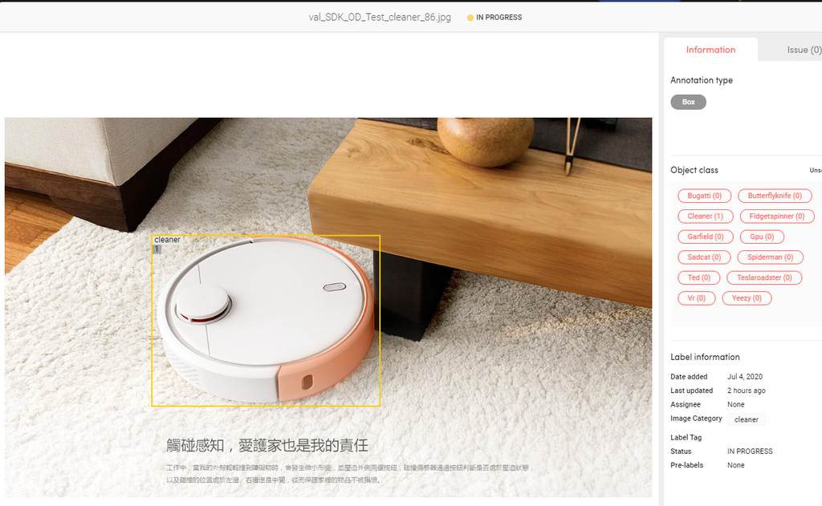